# Notes on Ch 27: A Field Guide to Base R

The Caveman Coder

2025-08-18

Topics covered:

- Subsetting with `[]`
- Subsetting with `[[]]`
- Subsetting with `$`
- `For` loops
- Essential plotting functions

### Prerequisites

```r
library(tidyverse)
```

## Selecting multiple elements with `[]`

### Subsetting vectors

```r
# Accessing elements by position
x <- c("one", "two", "three", "four", "five")

x[c(3, 2, 5)]
```

```
## [1] "three" "two"   "five"
```

Since you can repeatedly access a postion, the term “subsetting” is actually a misnomer:

```r
x[c(1, 1, 5, 5, 5, 2)]
```

```
## [1] "one"  "one"  "five" "five" "five" "two"
```

Dropping the elements at specified positions using negative index positions:

```r
x[c(-1, -3, -5)]
```

```
## [1] "two"  "four"
```

Subsetting with a logical vector:

```r
x <- c(10, 3, NA, 5, 8, 1, NA)


# All non-missing values of x
x[!is.na(x)]
```

```
## [1] 10  3  5  8  1
```

```r
# All even (or missing!) values of x
x[x %% 2 == 0]
```

```
## [1] 10 NA  8 NA
```

Unlike `filter()`, `NA` indices will be included in the output as `NA`s.

Subsetting with a character vector:

```r
x <- c(abc = 1, def = 2, xyz = 5)
x[c("xyz", "def")]
```

```
## xyz def
##   5   2
```

Subsetting with “nothing” returns the entire vector:

```r
x[]
```

```
## abc def xyz
##   1   2   5
```

This is a feature, not a bug. Useful when subsetting 2d structures like tibbles.

### Subsetting data frames

Format is `df[rows, columns]`.

Examples:

```r
df <- tibble(
  x = 1:3,
  y = c("a", "e", "f"),
  z = runif(3)
)

# Selecting the first row and second column
df[1, 2]
```

```
## # A tibble: 1 × 1
##   y
##   <chr>
## 1 a
```

```r
# Selecting all rows and columns x and y
df[, c("x", "y")]
```

```
## # A tibble: 3 × 2
##       x y
##   <int> <chr>
## 1     1 a
## 2     2 e
## 3     3 f
```

```r
# Selecting rows where x is greater than 1 and all columns
df[df$x > 1, ]
```

```
## # A tibble: 2 × 3
##       x y         z
##   <int> <chr> <dbl>
## 1     2 e     0.435
## 2     3 f     0.799
```

The dollar sign `$` is used to access the column name.

In many applications, a tibble and data frame can be used interchangeably, but in base R, it is important to make a distinction between them: If the target object is a data frame, subsetting a single column with `[]` returns a vector, and subsetting multiple columns with `[]` returns a data frame. If the target object is a tibble, subsetting with `[]` will always return a tibble.

```r
# Dataframe
df1 <- data.frame(x = 1:3)
df1[, "x"]
```

```
## [1] 1 2 3
```

```r
# Tibble
df2 <- tibble(x = 1:3)
df2[, "x"]
```

```
## # A tibble: 3 × 1
##       x
##   <int>
## 1     1
## 2     2
## 3     3
```

To avoid this ambiguity, we can use the argument `drop = FALSE` with dataframes:

```r
df1[, "x", drop = FALSE]
```

```
##   x
## 1 1
## 2 2
## 3 3
```

### `dplyr` equivalents

The dplyr function `filter()` is equivalent to subsetting rows with a logical vector, with the missing values excluded:

```r
df <- tibble(
  x = c(2, 3, 1, 1, NA),
  y = letters[1:5],
  z = runif(5)
)

df |> filter(x > 1)
```

```
## # A tibble: 2 × 3
##       x y         z
##   <dbl> <chr> <dbl>
## 1     2 a     0.839
## 2     3 b     0.352
```

```r
# same as
df[!is.na(df$x) & df$x > 1, ]
```

```
## # A tibble: 2 × 3
##       x y         z
##   <dbl> <chr> <dbl>
## 1     2 a     0.839
## 2     3 b     0.352
```

```r
# same as
df[which(df$x > 1), ]
```

```
## # A tibble: 2 × 3
##       x y         z
##   <dbl> <chr> <dbl>
## 1     2 a     0.839
## 2     3 b     0.352
```

The dplyr function `arrange()` is equivalent to subsetting the rows with an integer vector created with `order()`:

```r
df |> arrange(x, y)
```

```
## # A tibble: 5 × 3
##       x y         z
##   <dbl> <chr> <dbl>
## 1     1 c     0.682
## 2     1 d     0.110
## 3     2 a     0.839
## 4     3 b     0.352
## 5    NA e     0.232
```

```r
# same as
df[order(df$x, df$y), ]
```

```
## # A tibble: 5 × 3
##       x y         z
##   <dbl> <chr> <dbl>
## 1     1 c     0.682
## 2     1 d     0.110
## 3     2 a     0.839
## 4     3 b     0.352
## 5    NA e     0.232
```

Both dplyr functions `select()` and `relocate()` are similar to subsetting the columns with a character vector:

```r
df |> select(x, z)
```

```
## # A tibble: 5 × 2
##       x     z
##   <dbl> <dbl>
## 1     2 0.839
## 2     3 0.352
## 3     1 0.682
## 4     1 0.110
## 5    NA 0.232
```

```r
# same as
df[, c("x", "z")]
```

```
## # A tibble: 5 × 2
##       x     z
##   <dbl> <dbl>
## 1     2 0.839
## 2     3 0.352
## 3     1 0.682
## 4     1 0.110
## 5    NA 0.232
```

The base R function `subset()` combines the features of the dplyr functions `filter()` and `select()`:

```r
df |>
  filter(x > 1) |>
  select(y, z)
```

```
## # A tibble: 2 × 2
##   y         z
##   <chr> <dbl>
## 1 a     0.839
## 2 b     0.352
```

```r
# same as
df |> subset(x > 1, c(y, z))
```

```
## # A tibble: 2 × 2
##   y         z
##   <chr> <dbl>
## 1 a     0.839
## 2 b     0.352
```

### Exercises

1. Create functions that take a vector as input and return:
1. The elements at even-numbered positions.
2. Every element except the last value.
3. Only even values (and no missing value).
2. Why is `x[-which(x > 0)]` not the same as `x[x <= 0]`? Read the documentation for `which()` and do some experiments to figure it out.

## Selecting a single element with `$` and `[[]]`

These two are used to extract a single element.

### Data frames

`$` is specialized to access by column name, whil `[[]]` is used to access by position or by name:

```r
tb <- tibble(
  x = 1:4,
  y = c(10, 4, 1, 21)
)

# by position
tb[[1]]
```

```
## [1] 1 2 3 4
```

```r
# by name
tb[["x"]]
```

```
## [1] 1 2 3 4
```

```r
tb$x
```

```
## [1] 1 2 3 4
```

Both can also be used to create new columnms – the base R equivalent to `mutate()`:

```r
tb$z <- tb$x + tb$y
tb
```

```
## # A tibble: 4 × 3
##       x     y     z
##   <int> <dbl> <dbl>
## 1     1    10    11
## 2     2     4     6
## 3     3     1     4
## 4     4    21    25
```

The `$` accessor is very convenient to use when performing quick summaries:

```r
max(diamonds$carat)
```

```
## [1] 5.01
```

```r
levels(diamonds$cut)
```

```
## [1] "Fair"      "Good"      "Very Good" "Premium"   "Ideal"
```

In dplyr, `pull()` takes a variable name or variable position and returns just that column, and can be equivalent to the use of accessors in the code above:

```r
diamonds |> pull(carat) |> max()
```

```
## [1] 5.01
```

```r
diamonds |> pull(cut) |> levels()
```

```
## [1] "Fair"      "Good"      "Very Good" "Premium"   "Ideal"
```

### Tibbles

The dollar `$` accessor performs partial matching when used on dataframes:

```r
df <- data.frame(x1 = 1)
df$x
```

```
## [1] 1
```

```r
df$z
```

When used in tibbles, the `$` acessor is more strict:

```r
tb <- tibble(x1 = 1)

tb$x
```

```r
tb$z
```

Here is a”joke” to remember this distinction between tibbles and dataframes:

> Tibbles are lazy and surly: they do less and complain more.

### Lists

The `$` and `[[]]` “accessors extract a single component from a list:

```r
l <- list(
  a = 1:3,
  b = "a string",
  c = pi,
  d = list(-1, -5)
)

str(l[1:2])
```

```
## List of 2
##  $ a: int [1:3] 1 2 3
##  $ b: chr "a string"
```

```r
str(l[[1]])
```

```
##  int [1:3] 1 2 3
```

```r
str(l[1])
```

```
## List of 1
##  $ a: int [1:3] 1 2 3
```

```r
str(l[4])
```

```
## List of 1
##  $ d:List of 2
##   ..$ : num -1
##   ..$ : num -5
```

```r
str(l[[4]])
```

```
## List of 2
##  $ : num -1
##  $ : num -5
```

```r
str(l$a)
```

```
##  int [1:3] 1 2 3
```

Consider this analogy: A pepper shaker that contains sachets of ground pepper.

- `pepper[1]` refers to a pepper shaker containing a single sachet.
- `pepper[2]` refers to the same pepper shaker containing the second sachet.
- `pepper[1:2]`refers to the same pepper shaker containing the first and second sachet.
- `pepper[[1]]` extracts the first pepper sachet itself.

## Exercises

1. What happens when you use `[[]]` with a positive integer that’s bigger than the length of the vector? What happens when you subset with a name that doesn’t exist?
2. What would `pepper[[1]][1]` be? What about `pepper[[1]][[1]]?

## Apply family

- The most important function in this family is the `lapply()` function, which can be used to replace every `map()` function, if desired.
- There is no base R equivalent to `across()`, but using `[]` with `lapply()` can achieve something close to it.

Example:

```r
df <- tibble(
  a = 1,
  b = 2,
  c = "a",
  d = "b",
  e = 4
)

# First find numeric columns
num_cols <- sapply(df, is.numeric)
num_cols
```

```
##     a     b     c     d     e
##  TRUE  TRUE FALSE FALSE  TRUE
```

```r
# Then transform each column with lapply() and replace the
# original values.
df[, num_cols]
```

[output not shown]

[output not shown]

```
## # A tibble: 1 × 3
##       a     b     e
##   <dbl> <dbl> <dbl>
## 1     1     2     4
```

```r
df
```

```
## # A tibble: 1 × 5
##       a     b c     d         e
##   <dbl> <dbl> <chr> <chr> <dbl>
## 1     1     2 a     b         4
```

`sapply()` is similar to `lapply()`, but the former always tries to simplify the result, hence the `s` in the name.

- The authors don’t recommend using this for programming, because the simplification can fail and can give unexpected results.
- Base R provides a stricter version of `sapply()`, called `vapply()` – short for vector apply.

Example using `vapply()` instead of `sapply()`:

```r
vapply(df, is.numeric, logical(1))
```

```
##     a     b     c     d     e
##  TRUE  TRUE FALSE FALSE  TRUE
```

Example using `tapply()`, which computes a single grouped summary:

```r
diamonds |>
  group_by(cut) |>
  summarize(price = mean(price))
```

```
## # A tibble: 5 × 2
##   cut       price
##   <ord>     <dbl>
## 1 Fair      4359.
## 2 Good      3929.
## 3 Very Good 3982.
## 4 Premium   4584.
## 5 Ideal     3458.
```

```r
tapply(diamonds$price, diamonds$cut, mean)
```

```
##      Fair      Good Very Good   Premium     Ideal
##  4358.758  3928.864  3981.760  4584.258  3457.542
```

## `for` loops

Basic structure:

```r
for (element in vector) {
  # do something with element
}
```

The most straighforward use of `for` loops is to achieve the same effect as `walk()` – call some function with a side-effect on each element of a list.

Example:

```r
# version using walk
paths |> walk(append_file)

# version using for-loop
for (paths in paths) {
  append_file(paths)
}
```

To iterate over the list of file paths, it is better to iterate over their indices, rather than over the elements. To effectively do this, the function `seq_along()` can be used. The final function becomes:

```r
for (i in seq_along(paths)) {
 files[[i]] <- readxl::read_excel(paths[[i]])
}
```

Finally, to combine the list of tibbles into a single tibble, the combination of `do.call()` and `rbind()` can be used:

```r
do.call() + rbind()
```

```r
out <- NULL
for (path in paths) {
  out <- rbind(out, readxl::read_excel(path))
}
```

## Plots

There are two main types of base plot (for data science?) are scatterplots and histograms. In base R, we can make these plots using `plot()` and `hist()`.

Example:

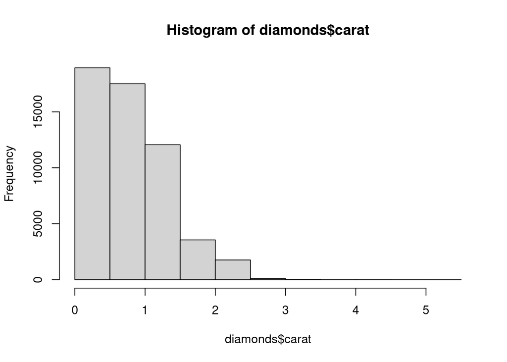

```r
hist(diamonds$carat)
```

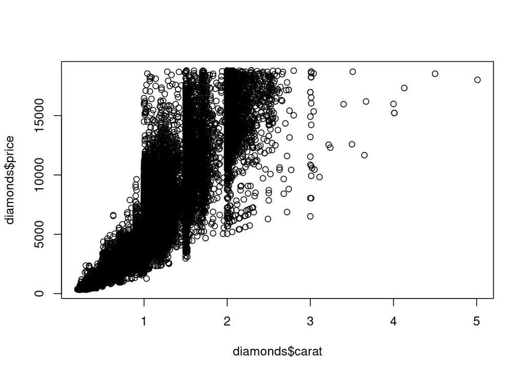

```r
plot(diamonds$carat, diamonds$price)
```